# Assignment 2 - KNN Manasa Pullabhatla

#Summary ## 1. Age = 40, Experience = 10, Income = 84, Family = 2, CCAvg = 2, Education_1 = 0, Education_2 = 1, Education_3 = 0, Mortgage = 0, Securities Account = 0, CD Account = 0, Online = 1, and Credit Card = 1. Perform a k-NN classification with all predictors except ID and ZIP code using k = 1. Remember to transform categorical predictors with more than two categories into dummy variables first. Specify the success class as 1 (loan acceptance), and use the default cutoff value of 0.5. How would this customer be classified?

##Interpretation - The customer is categorized as 0 when k=1, which denotes that the loan is not accepted. Due to the fact that factor 1 is recognized as loan acceptance while factor 0 is not.

##2 What is a choice of k that balances between overfitting and ignoring the predictor information?

#Interpretation - K value in a way that avoids both overfitting and neglecting the predictor information is 1, K=1

##3 Show the confusion matrix for the validation data that results from using the best k.

#Interpretation - Kindly look at the below output for Question 3

##4 Consider the following customer: Age = 40, Experience = 10, Income = 84, #Interpretation - Family = 2, CCAvg = 2, Education_1 = 0, Education_2 = 1, Education_3 = 0,Mortgage = 0, Securities Account = 0, CD Account = 0, Online = 1 and CreditCard = 1. Classify the customer using the best k.

##Interpretation - By selecting the best k, the consumer is given the classification of 0, which denotes that the loan is rejected.

##5 . Repartition the data, this time into training, validation, and test sets (50% : 30% : 20%). Apply the k-NN method with the k chosen above. Compare the confusion matrix of the test set with that of the training and validation sets. Comment on the differences and their reason.

##Interpretation - We will not take training into account when comparing the test with training and validation because a model will typically produce 100% accuracy when it has the observed data.By comparing the Test data to the Validation data, we can see that the Test data has less errors, more accuracy, and better sensitivity, indicating that the model performs well on the data that is not known.

```r
data1 <- read.csv("C:/Users/Sailaja/Desktop/UniversalBank.csv")
str(data1)
```

```
## 'data.frame':    5000 obs. of  14 variables:
##  $ ID                : int  1 2 3 4 5 6 7 8 9 10 ...
##  $ Age               : int  25 45 39 35 35 37 53 50 35 34 ...
##  $ Experience        : int  1 19 15 9 8 13 27 24 10 9 ...
##  $ Income            : int  49 34 11 100 45 29 72 22 81 180 ...
##  $ ZIP.Code          : int  91107 90089 94720 94112 91330 92121 91711 93943 90089 93023 ...
##  $ Family            : int  4 3 1 1 4 4 2 1 3 1 ...
##  $ CCAvg             : num  1.6 1.5 1 2.7 1 0.4 1.5 0.3 0.6 8.9 ...
##  $ Education         : int  1 1 1 2 2 2 2 3 2 3 ...
##  $ Mortgage          : int  0 0 0 0 0 155 0 0 104 0 ...
##  $ Personal.Loan     : int  0 0 0 0 0 0 0 0 0 1 ...
##  $ Securities.Account: int  1 1 0 0 0 0 0 0 0 0 ...
##  $ CD.Account        : int  0 0 0 0 0 0 0 0 0 0 ...
##  $ Online            : int  0 0 0 0 0 1 1 0 1 0 ...
##  $ CreditCard        : int  0 0 0 0 1 0 0 1 0 0 ...
```

```r
library("ISLR")
library("caret")
```

```r
library("class")
library("ggplot2")
library("gmodels")
```

#Data cleaning

```r
data1 <- data1[,c(-1,-5)]
head(data1, n=5)
```

|  | Age | Experience | Income | Family | CCAvg | Education | Mortgage | Personal.Loan | Securities.Account | CD.Account | Online | CreditCard |
| --- | --- | --- | --- | --- | --- | --- | --- | --- | --- | --- | --- | --- |
| 1 | 25 | 1 | 49 | 4 | 1.6 | 1 | 0 | 0 | 1 | 0 | 0 | 0 |
| 2 | 45 | 19 | 34 | 3 | 1.5 | 1 | 0 | 0 | 1 | 0 | 0 | 0 |
| 3 | 39 | 15 | 11 | 1 | 1.0 | 1 | 0 | 0 | 0 | 0 | 0 | 0 |
| 4 | 35 | 9 | 100 | 1 | 2.7 | 2 | 0 | 0 | 0 | 0 | 0 | 0 |
| 5 | 35 | 8 | 45 | 4 | 1.0 | 2 | 0 | 0 | 0 | 0 | 0 | 1 |

```r
test.na <- is.na.data.frame("data1")

#Converting data types of attributes
data1$Education <- as.character(data1$Education)
data1$Personal.Loan <- as.factor(data1$Personal.Loan)
#is.character(data1$Personal.loan)

#Dumming Variable

DummyVariables <- dummyVars(~Education, data1)
data2 <- predict(DummyVariables,data1)

##Combining Data
data3 <- data1[,-6]
data4 <- cbind(data3, data2)
colnames(data4)
```

```
##  [1] "Age"                "Experience"         "Income"
##  [4] "Family"             "CCAvg"              "Mortgage"
##  [7] "Personal.Loan"      "Securities.Account" "CD.Account"
## [10] "Online"             "CreditCard"         "Education1"
## [13] "Education2"         "Education3"
```

#Data Partition and Normalization

```r
set.seed(123)
Data_Part_Train <- createDataPartition(data4$Personal.Loan, p=0.6, list=F)
Train_Data <- data4[Data_Part_Train,]
Validation_Data <- data4[-Data_Part_Train,]

#Normalizing the training dataset
Model_Z_Normalized <- preProcess(Train_Data[,-c(7,12:14)], method=c("center","scale"))

Normalized_Data_Train <- predict(Model_Z_Normalized, Train_Data)

Normalized_Data_Validation <- predict(Model_Z_Normalized, Validation_Data)

#summary(Normalized_Data_Train)
#summary(Normalized_Data_Validation)
```

#Inserting a test set and normalizing it

```r
test_data <- cbind.data.frame(Age = 40,Experience = 10, Income = 84,Family = 2,
                        CCAvg =2, Mortgage = 0, Securities.Account = 0,
                        CD.Account =0, Online =1, CreditCard = 1,
                        Education1 = 0, Education2 = 1, Education3 = 0)

Test_Normalized <- predict(Model_Z_Normalized, test_data)
```

#1 Running the Knn model on the test dataset with k=1

```r
Train_Predictors <- Normalized_Data_Train[,-7]
Validaion_Predictors <- Normalized_Data_Validation[,-7]

Train_Labels <- Normalized_Data_Train[,7]
Validation_Labels <- Normalized_Data_Validation[,7]

Predicted_K <- knn(Train_Predictors, Test_Normalized, cl=Train_Labels, k=1)

head(Predicted_K)
```

```
## [1] 0
## Levels: 0 1
```

The customer is categorized as 0 when k=1, which denotes that the loan is not accepted. Due to the fact that factor 1 is recognized as loan acceptance while factor 0 is not.

#2 Selecting k in a way that avoids both overfitting and neglecting the predictor information

```r
set.seed(455)
search_grid <- expand.grid(k=c(1:30))
#trtcontrol <- trainControl(method="repeatedcv")
model <- train(Personal.Loan~Age+Experience+Income+Family+CCAvg+Mortgage+Securities.Account+CD.Account+Online+CreditCard+Education1+Education2+Education3, data=Normalized_Data_Train, method="knn", tuneGrid = search_grid)
model
```

```
## k-Nearest Neighbors
##
## 3000 samples
##   13 predictor
##    2 classes: '0', '1'
##
## No pre-processing
## Resampling: Bootstrapped (25 reps)
## Summary of sample sizes: 3000, 3000, 3000, 3000, 3000, 3000, ...
## Resampling results across tuning parameters:
##
##   k   Accuracy   Kappa
##    1  0.9486329  0.6739443
##    2  0.9405480  0.6118584
##    3  0.9403636  0.5980966
```

[output cut: 30 more lines]

```r
best_k <- model$bestTune[[1]]
best_k
```

```
## [1] 1
```

K value in a way that avoids both overfitting and neglecting the predictor information is 1, K=1

#Plotting Model

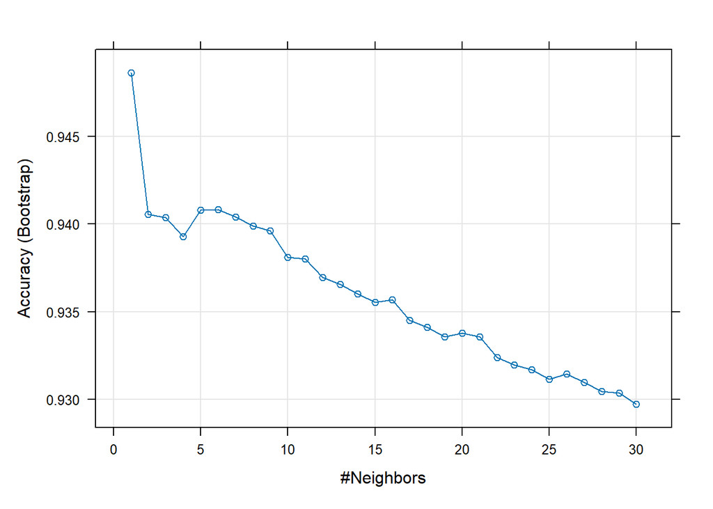

```r
plot(model)
```

#3 confusion matrix being applied to the validation data

```r
pred_training <- predict(model,Normalized_Data_Validation[,-7])
confusionMatrix(pred_training, Validation_Labels)
```

```
## Confusion Matrix and Statistics
##
##           Reference
## Prediction    0    1
##          0 1789   54
##          1   19  138
##
##                Accuracy : 0.9635
##                  95% CI : (0.9543, 0.9713)
##     No Information Rate : 0.904
##     P-Value [Acc > NIR] : < 2.2e-16
##
##                   Kappa : 0.7711
##
##  Mcnemar's Test P-Value : 6.909e-05
##
##             Sensitivity : 0.9895
##             Specificity : 0.7188
##          Pos Pred Value : 0.9707
##          Neg Pred Value : 0.8790
##              Prevalence : 0.9040
##          Detection Rate : 0.8945
##    Detection Prevalence : 0.9215
##       Balanced Accuracy : 0.8541
##
##        'Positive' Class : 0
##
```

#4 Running the test data with best k choosen above

```r
test_best_k <- knn(Train_Predictors, Test_Normalized, cl=Train_Labels, k=best_k)
head(test_best_k)
```

```
## [1] 0
## Levels: 0 1
```

##By selecting the best k, the consumer is given the classification of 0, which denotes that the loan is rejected.

#5.Repartitioning the data into training(60%), validation(20%) and test(20%) and running the entire model with best k

```r
set.seed(422)
data_part <- createDataPartition(data4$Personal.Loan, p=0.6, list = F)
n_train_data <- data4[data_part,]
nd_test_data <- data4[-data_part,]

data_part_v <- createDataPartition(nd_test_data$Personal.Loan,p=0.5, list =F)
n_validate_data <- nd_test_data[data_part_v,]
n_test_data <- nd_test_data[-data_part_v,]

#Normalization
norm_m <- preProcess(n_train_data[,-c(7,12:14)],method=c("center","scale"))

train_z <- predict(norm_m, n_train_data)
validate_z <- predict(norm_m, n_validate_data)
test_z <- predict(norm_m, n_test_data)

#Defining the predictors and labels
n_train_predictor <- train_z[,-7]
n_validate_predictor <- validate_z[,-7]
n_test_predictor <- test_z[,-7]

n_train_labels <- train_z[,7]
n_validate_labels <- validate_z[,7]
n_test_labels <- test_z[,7]

#running the knn model over train dataset
n_model <- knn(n_train_predictor,n_train_predictor,cl=n_train_labels,k=best_k)
head(n_model)
```

```
## [1] 0 0 0 0 0 1
## Levels: 0 1
```

```r
#running the knn model over validation dataset
n_model1 <- knn(n_train_predictor,n_validate_predictor,cl=n_train_labels,k=best_k)

head(n_model1)
```

```
## [1] 0 0 0 0 0 0
## Levels: 0 1
```

```r
#running the knn model over test dataset
n_model2 <- knn(n_train_predictor,n_test_predictor,cl=n_train_labels,k=best_k)
head(n_model2)
```

```
## [1] 0 0 1 0 1 0
## Levels: 0 1
```

```r
confusionMatrix(n_model,n_train_labels)
```

```
## Confusion Matrix and Statistics
##
##           Reference
## Prediction    0    1
##          0 2712    0
##          1    0  288
##
##                Accuracy : 1
##                  95% CI : (0.9988, 1)
##     No Information Rate : 0.904
##     P-Value [Acc > NIR] : < 2.2e-16
##
##                   Kappa : 1
##
##  Mcnemar's Test P-Value : NA
##
##             Sensitivity : 1.000
##             Specificity : 1.000
##          Pos Pred Value : 1.000
##          Neg Pred Value : 1.000
##              Prevalence : 0.904
##          Detection Rate : 0.904
##    Detection Prevalence : 0.904
##       Balanced Accuracy : 1.000
##
##        'Positive' Class : 0
##
```

#Train_Data - Miscalculations = 0 Accuracy = 1 Sensitivity = 1 #This is due to the fact that the train and test datasets are identical, yielding 100% Accuracy and 0 Miscalculations.

```r
confusionMatrix(n_model1,n_validate_labels)
```

```
## Confusion Matrix and Statistics
##
##           Reference
## Prediction   0   1
##          0 893  44
##          1  11  52
##
##                Accuracy : 0.945
##                  95% CI : (0.929, 0.9583)
##     No Information Rate : 0.904
##     P-Value [Acc > NIR] : 1.502e-06
##
##                   Kappa : 0.6256
##
##  Mcnemar's Test P-Value : 1.597e-05
##
##             Sensitivity : 0.9878
##             Specificity : 0.5417
##          Pos Pred Value : 0.9530
##          Neg Pred Value : 0.8254
##              Prevalence : 0.9040
##          Detection Rate : 0.8930
##    Detection Prevalence : 0.9370
##       Balanced Accuracy : 0.7647
##
##        'Positive' Class : 0
##
```

#Validation data Miscalculations = 44+11 = 55 Accuracy= 0.945 Sensitivity=0.9878

```r
confusionMatrix(n_model2,n_test_labels)
```

```
## Confusion Matrix and Statistics
##
##           Reference
## Prediction   0   1
##          0 894  27
##          1  10  69
##
##                Accuracy : 0.963
##                  95% CI : (0.9494, 0.9738)
##     No Information Rate : 0.904
##     P-Value [Acc > NIR] : 7.83e-13
##
##                   Kappa : 0.7685
##
##  Mcnemar's Test P-Value : 0.008529
##
##             Sensitivity : 0.9889
##             Specificity : 0.7188
##          Pos Pred Value : 0.9707
##          Neg Pred Value : 0.8734
##              Prevalence : 0.9040
##          Detection Rate : 0.8940
##    Detection Prevalence : 0.9210
##       Balanced Accuracy : 0.8538
##
##        'Positive' Class : 0
##
```

#Test_Data - Miscalculations 10+27 = 37 Accuracy =0.963 Sensitivity =0.9889

#Interpretation We will not take training into account when comparing the test with training and validation because a model will typically produce 100% accuracy when it has the observed data.

Miscalculations: Validation - 55, Test - 37

Accuracy: Validation - 0.945, Test -0.963

Sensitivity: Validation - 0.9878, Test - 0.9889

#By comparing the Test data to the Validation data, we can see that the Test data has less errors, more accuracy, and better sensitivity, indicating that the model performs well on the data that is not known.